# Podcast Reviews Analysis

### Podcasts DataFrame

```python
analyze_dataframe(podcasts_df, "Podcasts")
```

```
Podcasts table:

Columns: ['podcast_id', 'itunes_id', 'slug', 'itunes_url', 'title']

Summary statistics:
          itunes_id
count  1.100240e+05
mean   1.309424e+09
std    3.575526e+08
min    7.332927e+07
25%    1.227235e+09
50%    1.467889e+09
75%    1.528936e+09
max    1.665764e+09

Number of duplicates: 0

Number of missing values:
podcast_id    0
itunes_id     0
slug          0
itunes_url    0
title         0
dtype: int64

First few rows:
                         podcast_id   itunes_id  \
0  a00018b54eb342567c94dacfb2a3e504  1313466221
1  a00043d34e734b09246d17dc5d56f63c   158973461
2  a0004b1ef445af9dc84dad1e7821b1e3   139076942
3  a00071f9aaae9ac725c3a586701abf4d  1332508972
4  a000a500f06555f81220c3eb641aded7  1544900779

                                    slug  \
0                         scaling-global
1  cornerstone-baptist-church-of-orlando
2            mystery-dancing-in-the-dark
3                      kts-money-matters
4       word-on-the-street-w-dreak-swift

                                          itunes_url  \
0  https://podcasts.apple.com/us/podcast/scaling-...
1  https://podcasts.apple.com/us/podcast/cornerst...
2  https://podcasts.apple.com/us/podcast/mystery-...
3  https://podcasts.apple.com/us/podcast/kts-mone...
4  https://podcasts.apple.com/us/podcast/word-on-...

                                   title
0                         Scaling Global
1  Cornerstone Baptist Church of Orlando
2           Mystery: Dancing in the Dark
3                      KTs Money Matters
4      Word on the Street w/ Dreak Swift
```

- The table contains **110,024** rows and **5** columns: 'podcast_id', 'itunes_id', 'slug', 'itunes_url', and 'title'.
- There are **no** missing values or duplicate rows in the data.

```python
podcasts_df = parallel_process(podcasts_df, n_processes=8)

podcasts_df = to_lowercase(podcasts_df, ["title"])
podcasts_df = remove_punctuation(podcasts_df, ["title"])
podcasts_df = remove_stopwords(podcasts_df, ["title"])

save_dataframe_to_sql(podcasts_df, conn, "podcasts_cleaned")
podcasts_cleaned_df = load_data_from_sql("podcasts_cleaned", conn)
```

1. **remove_non_english**: Removed rows from `podcasts_df` where the "title" column contained non-English content.
2. **to_lowercase**: Converted text in the "title" column of `podcasts_df` to lowercase.
3. **remove_punctuation**: Removed punctuation from the "title" column in `podcasts_df`.
4. **remove_stopwords**: Removed stopwords from the "title" column in `podcasts_df`.

### Runs DataFrame

```python
analyze_dataframe(runs_df, "Runs")
```

```
Runs table:

Columns: ['run_at', 'max_rowid', 'reviews_added']

Summary statistics:
                              run_at     max_rowid  reviews_added
count                             16  1.600000e+01   1.600000e+01
mean   2022-04-01 18:28:13.437499904  4.368318e+06   1.292206e+05
min              2021-05-10 02:53:00  3.266481e+06   0.000000e+00
25%              2021-08-25 17:59:03  3.382702e+06   1.281800e+04
50%              2022-06-14 05:59:54  4.167376e+06   1.908900e+04
75%    2022-09-13 17:05:22.249999872  5.330927e+06   3.799075e+04
max              2023-02-18 02:11:53  5.599789e+06   1.215223e+06
std                              NaN  9.678974e+05   3.194665e+05

Number of duplicates: 0

Number of missing values:
run_at           0
max_rowid        0
reviews_added    0
dtype: int64

First few rows:
               run_at  max_rowid  reviews_added
0 2021-05-10 02:53:00    3266481        1215223
1 2021-06-06 21:34:36    3300773          13139
2 2021-07-02 18:04:55    3329699          11561
3 2021-08-01 17:54:42    3360315          11855
4 2021-09-02 18:00:30    3390165          11714
```

- The table contains **16** rows and **3** columns: 'run_at', 'max_rowid', and 'reviews_added'.
- The 'max_rowid' column has a mean value of approximately **4,368,318**, with a standard deviation of **967,897**.
- The minimum 'max_rowid' is **3,266,481** and the maximum is **5,599,789**.
- The 'reviews_added' column has a mean value of approximately **129,220**, with a standard deviation of **319,466**.
- There are **no** missing values or duplicate rows in the data.

### Reviews DataFrame

```python
analyze_dataframe(reviews_df, "Reviews")
```

```
Reviews table:

Columns: ['podcast_id', 'title', 'content', 'rating', 'author_id', 'created_at']

Summary statistics:
             rating
count  2.067529e+06
mean   4.627081e+00
std    1.045882e+00
min    1.000000e+00
25%    5.000000e+00
50%    5.000000e+00
75%    5.000000e+00
max    5.000000e+00

Number of duplicates: 655

Number of missing values:
podcast_id    0
title         0
content       0
rating        0
author_id     0
created_at    0
dtype: int64

First few rows:
                         podcast_id  \
0  c61aa81c9b929a66f0c1db6cbe5d8548
1  c61aa81c9b929a66f0c1db6cbe5d8548
2  ad4f2bf69c72b8db75978423c25f379e
3  ad4f2bf69c72b8db75978423c25f379e
4  ad4f2bf69c72b8db75978423c25f379e

                                              title  \
0                               really interesting!
1  Must listen for anyone interested in the arts!!!
2                                 nauseatingly left
3                                   Diverse stories
4                                              👍👍👍👍

                                             content  rating        author_id  \
0  Thanks for providing these insights.  Really e...       5  F7E5A318989779D
1  Super excited to see this podcast grow. So man...       5  F6BF5472689BD12
2  I'm a liberal myself, but its pretty obvious a...       1  1AB95B8E6E1309E
3  I find Tedx talks very inspirational but I oft...       5  11BB760AA5DEBD1
4                I love this podcast, it is so good.       5  D86032C8E57D15A

                 created_at
0 2018-04-24 12:05:16-07:00
1 2018-05-09 18:14:32-07:00
2 2019-06-11 14:53:39-07:00
3 2018-05-31 13:08:09-07:00
4 2019-06-19 13:56:05-07:00
```

- The table contains **2,067,529** rows and **6** columns: 'podcast_id', 'title', 'content', 'rating', 'author_id', and 'created_at'.
- The 'rating' column has a mean value of approximately **4.63**, with a standard deviation of **1.05**.
- The minimum 'rating' is **1** and the maximum is **5**.
- There are **655** duplicate rows in the data.
- There are **no** missing values in the data.

```python
reviews_df = parallel_process(reviews_df, n_processes=8)

reviews_df = to_lowercase(reviews_df, ["title", "content"])
reviews_df = remove_punctuation(reviews_df, ["title", "content"])
reviews_df = remove_stopwords(reviews_df, ["title", "content"])
reviews_df = add_length_column(reviews_df, "content", "content_length")

save_dataframe_to_sql(reviews_df, conn, "reviews_cleaned")
reviews_cleaned_df = load_data_from_sql("reviews_cleaned", conn)
```

1. **remove_non_english**: Removed rows from `reviews_df` where the "title" and "content" columns contained non-English content.
2. **to_lowercase**: Converted text in the "title" and "content" columns of `reviews_df` to lowercase.
3. **remove_punctuation**: Removed punctuation from the "title" and "content" columns in `reviews_df`.
4. **remove_stopwords**: Removed stopwords from the "title" and "content" columns in `reviews_df`.
5. **add_length_column**: Added length of the `content` column `reviews_df`.

### Exploratory Data Analysis

Now that our data is cleaned, we can analyze podcast popularity. This includes investigating both the number of reviews received by each podcast and the potential correlation between review count and average rating.

```python
query = """SELECT p.title, COUNT(r.content) as review_count, r.rating as avg_rating
FROM podcasts_cleaned as p
JOIN reviews_cleaned as r
ON p.podcast_id = r.podcast_id
GROUP BY p.title
ORDER BY review_count DESC
LIMIT 5"""

podcast_review_counts = pd.read_sql_query(query, conn)

create_bar_chart(
    podcast_review_counts,
    "title",
    "review_count",
    "Title",
    "Review count",
    "Top 5 Podcasts by Review Count",
    "#dcb0f2",
    "../images/top_5_podcasts_by_review_count.png"
)
```

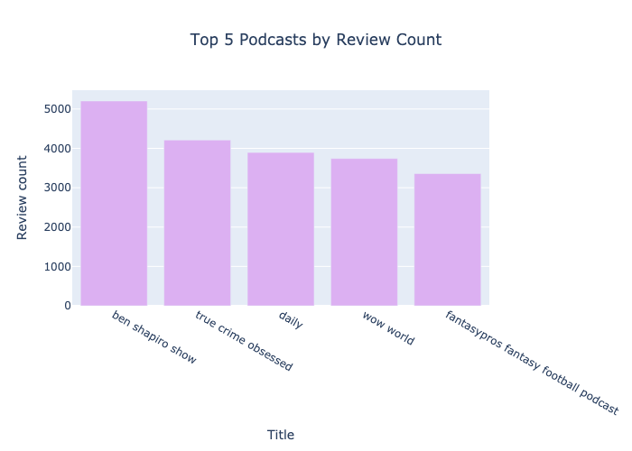

```python
Image(filename="../images/top_5_podcasts_by_review_count.png")
```

The **number of reviews** a podcast receives can be an indicator of its **popularity**.

Next, we can explore the relationship between the number of reviews and the average rating of a podcast. Specifically, we will check if there is a **correlation** between these two factors.

```python
sample_size = 50000

query = f"""
SELECT r.podcast_id,
p.title,
COUNT(r.rating) as num_reviews,
AVG(r.rating) as avg_rating
FROM (SELECT * FROM reviews_cleaned ORDER BY RANDOM() LIMIT {sample_size}) as r
JOIN podcasts_cleaned as p ON r.podcast_id = p.podcast_id
GROUP BY r.podcast_id, p.title"""

podcast_avg_ratings = pd.read_sql_query(query, conn)

correlation = podcast_avg_ratings["num_reviews"].corr(podcast_avg_ratings["avg_rating"])

print(
    f"The correlation between the number of reviews and the average rating is {correlation}"
)

create_scatter_plot(
    podcast_avg_ratings,
    "num_reviews",
    "avg_rating",
    "Number of reviews",
    "Average rating",
    "Number of Reviews vs. Average Rating",
    "#dcb0f2",
    "rgb(128, 0, 128)",
    "../images/number_of_reviews_vs_average_rating.png"
)
```

```
The correlation between the number of reviews and the average rating is -0.08419362311496865
```

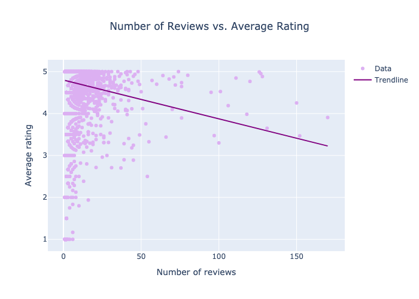

```python
Image(filename="../images/number_of_reviews_vs_average_rating.png")
```

Based on the scatter plot, there is **no clear correlation** between the number of reviews and the average rating of a podcast.

So with that in mind, we can dig deeper and see if there is a correlation between the length of a review and the rating it gives. Our objective is to explore the potential association between the length of a review and the rating it receives. To address this, we propose the following hypotheses:

a. **Null Hypothesis (H0)**: There is no association between the length of a review and the rating it receives.

b. **Alternative Hypothesis (H1)**: There is a statistically significant association between the length of a review and the rating it receives.

Given that the rating is a categorical variable, we can employ Analysis of Variance (ANOVA) if one variable is categorical (rating) and the other is continuous (review length). ANOVA is a statistical method used to determine whether there are significant differences between the means of three or more independent groups. In this context, the groups would correspond to the different rating categories, and the continuous measure would be the review length.

We also compute the p-value, which provides the probability of observing our data (or data more extreme) assuming the null hypothesis is true. If the p-value is less than our chosen significance level (commonly 0.05), we reject the null hypothesis in favor of the alternative hypothesis. In simpler terms, if the p-value is less than 0.05, we conclude that there is a statistically significant association between review length and rating.

```python
sample_df = reviews_cleaned_df.sample(n=sample_size)

lengths = sample_df["content_length"]
ratings = sample_df["rating"]

create_box_plot(
    sample_df,
    "rating",
    "content_length",
    "Review Length vs Rating",
    "Rating",
    "Review Length",
    "#dcb0f2",
    "../images/review_length_vs_rating.png"
)

groups = [sample_df.loc[sample_df.rating == i, "content_length"] for i in range(1, 6)]

F, p = f_oneway(*groups)

print(f"F statistic: {F}")
print(f"p-value: {p}")
```

```
F statistic: 232.92963187877754
p-value: 1.5966844017614888e-198
```

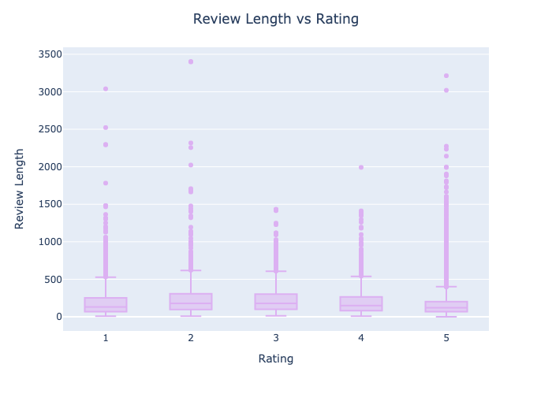

```python
Image(filename="../images/review_length_vs_rating.png")
```